# Cyclistic Bike-Share Analysis

Setu Garg

2024-09-19

## Introduction

This case study analyzes Cyclistic’s historical bike trip data to identify trends and differences between annual members and casual riders. The goal is to design marketing strategies aimed at converting casual riders into annual members.

## Business Task

Analyze the differences in bike usage patterns between annual members and casual riders to identify key factors that could influence casual riders to convert to annual memberships. Specifically, examine ride duration, frequency, popular routes, and usage times to develop targeted marketing strategies aimed at increasing the conversion rate of casual riders to annual members by 10% in the next fiscal year.

## Data Sources

The analysis is based on Cyclistic’s historical trip data from the first quarters of 2019 and 2020. Specifically, we are using the following datasets:

**Divvy Trips 2019 Q1 (January - March 2019)**

- Filename: Divvy_Trips_2019_Q1.csv
- Source: Provided by Cyclistic (Divvy)
- Time period: January 1, 2019 - March 31, 2019
- Number of rides: 365069

**Divvy Trips 2020 Q1 (January - March 2020)**

- Filename: Divvy_Trips_2020_Q1.csv
- Source: Provided by Cyclistic (Divvy)
- Time period: January 1, 2020 - March 31, 2020
- Number of rides: 426887

Total number of rides: **791956**

```r
# Load required libraries
library(tidyverse)
library(lubridate)
library(ggplot2)
```

```r
# Load the datasets
q1_2019 <- read_csv("Divvy_Trips_2019_Q1.csv")
q1_2020 <- read_csv("Divvy_Trips_2020_Q1.csv")

# Display the first few rows of each dataset
head(q1_2019)
```

```
## # A tibble: 6 × 12
##    trip_id start_time          end_time            bikeid tripduration
##      <dbl> <dttm>              <dttm>               <dbl>        <dbl>
## 1 21742443 2019-01-01 00:04:37 2019-01-01 00:11:07   2167          390
## 2 21742444 2019-01-01 00:08:13 2019-01-01 00:15:34   4386          441
## 3 21742445 2019-01-01 00:13:23 2019-01-01 00:27:12   1524          829
## 4 21742446 2019-01-01 00:13:45 2019-01-01 00:43:28    252         1783
## 5 21742447 2019-01-01 00:14:52 2019-01-01 00:20:56   1170          364
## 6 21742448 2019-01-01 00:15:33 2019-01-01 00:19:09   2437          216
## # ℹ 7 more variables: from_station_id <dbl>, from_station_name <chr>,
## #   to_station_id <dbl>, to_station_name <chr>, usertype <chr>, gender <chr>,
## #   birthyear <dbl>
```

```r
head(q1_2020)
```

```
## # A tibble: 6 × 13
##   ride_id          rideable_type started_at          ended_at
##   <chr>            <chr>         <dttm>              <dttm>
## 1 EACB19130B0CDA4A docked_bike   2020-01-21 20:06:59 2020-01-21 20:14:30
## 2 8FED874C809DC021 docked_bike   2020-01-30 14:22:39 2020-01-30 14:26:22
## 3 789F3C21E472CA96 docked_bike   2020-01-09 19:29:26 2020-01-09 19:32:17
## 4 C9A388DAC6ABF313 docked_bike   2020-01-06 16:17:07 2020-01-06 16:25:56
## 5 943BC3CBECCFD662 docked_bike   2020-01-30 08:37:16 2020-01-30 08:42:48
## 6 6D9C8A6938165C11 docked_bike   2020-01-10 12:33:05 2020-01-10 12:37:54
## # ℹ 9 more variables: start_station_name <chr>, start_station_id <dbl>,
## #   end_station_name <chr>, end_station_id <dbl>, start_lat <dbl>,
## #   start_lng <dbl>, end_lat <dbl>, end_lng <dbl>, member_casual <chr>
```

```r
# For the 2019 Q1 dataset
num_rides_2019 <- nrow(q1_2019)
print(paste("Number of rides in 2019 Q1:", num_rides_2019))
```

```
## [1] "Number of rides in 2019 Q1: 365069"
```

```r
# For the 2020 Q1 dataset
num_rides_2020 <- nrow(q1_2020)
print(paste("Number of rides in 2020 Q1:", num_rides_2020))
```

```
## [1] "Number of rides in 2020 Q1: 426887"
```

```r
# Total number of rides in both datasets
total_rides <- num_rides_2019 + num_rides_2020
print(paste("Total number of rides:", total_rides))
```

```
## [1] "Total number of rides: 791956"
```

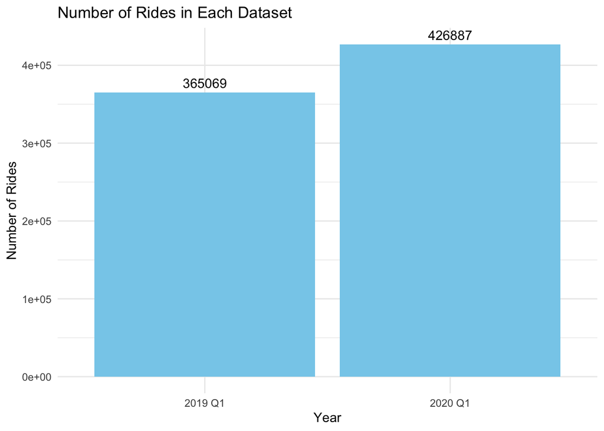

```r
library(ggplot2)

ride_counts <- data.frame(
  Year = c("2019 Q1", "2020 Q1"),
  Rides = c(num_rides_2019, num_rides_2020)
)

ggplot(ride_counts, aes(x = Year, y = Rides)) +
  geom_bar(stat = "identity", fill = "skyblue") +
  geom_text(aes(label = Rides), vjust = -0.5) +
  labs(title = "Number of Rides in Each Dataset",
       y = "Number of Rides") +
  theme_minimal()
```

## Data Cleaning and Preparation

For our analysis, we will inspect the data steps and identify discrepancies in the structure and formats. Then we will clean and prepare the data for our analysis.

```r
# Data Cleaning Steps for Cyclistic Bike-Share Analysis

# Load required libraries
library(tidyverse)
library(lubridate)

# Step 1: Load the datasets
q1_2019 <- read_csv("Divvy_Trips_2019_Q1.csv")
q1_2020 <- read_csv("Divvy_Trips_2020_Q1.csv")

# Step 2: Inspect the data
str(q1_2019)
```

```
## spc_tbl_ [365,069 × 12] (S3: spec_tbl_df/tbl_df/tbl/data.frame)
##  $ trip_id          : num [1:365069] 21742443 21742444 21742445 21742446 21742447 ...
##  $ start_time       : POSIXct[1:365069], format: "2019-01-01 00:04:37" "2019-01-01 00:08:13" ...
##  $ end_time         : POSIXct[1:365069], format: "2019-01-01 00:11:07" "2019-01-01 00:15:34" ...
##  $ bikeid           : num [1:365069] 2167 4386 1524 252 1170 ...
##  $ tripduration     : num [1:365069] 390 441 829 1783 364 ...
##  $ from_station_id  : num [1:365069] 199 44 15 123 173 98 98 211 150 268 ...
##  $ from_station_name: chr [1:365069] "Wabash Ave & Grand Ave" "State St & Randolph St" "Racine Ave & 18th St" "California Ave & Milwaukee Ave" ...
##  $ to_station_id    : num [1:365069] 84 624 644 176 35 49 49 142 148 141 ...
##  $ to_station_name  : chr [1:365069] "Milwaukee Ave & Grand Ave" "Dearborn St & Van Buren St (*)" "Western Ave & Fillmore St (*)" "Clark St & Elm St" ...
##  $ usertype         : chr [1:365069] "Subscriber" "Subscriber" "Subscriber" "Subscriber" ...
##  $ gender           : chr [1:365069] "Male" "Female" "Female" "Male" ...
##  $ birthyear        : num [1:365069] 1989 1990 1994 1993 1994 ...
##  - attr(*, "spec")=
##   .. cols(
##   ..   trip_id = col_double(),
##   ..   start_time = col_datetime(format = ""),
##   ..   end_time = col_datetime(format = ""),
##   ..   bikeid = col_double(),
##   ..   tripduration = col_number(),
##   ..   from_station_id = col_double(),
##   ..   from_station_name = col_character(),
##   ..   to_station_id = col_double(),
##   ..   to_station_name = col_character(),
##   ..   usertype = col_character(),
##   ..   gender = col_character(),
##   ..   birthyear = col_double()
##   .. )
##  - attr(*, "problems")=<externalptr>
```

```r
str(q1_2020)
```

```
## spc_tbl_ [426,887 × 13] (S3: spec_tbl_df/tbl_df/tbl/data.frame)
##  $ ride_id           : chr [1:426887] "EACB19130B0CDA4A" "8FED874C809DC021" "789F3C21E472CA96" "C9A388DAC6ABF313" ...
##  $ rideable_type     : chr [1:426887] "docked_bike" "docked_bike" "docked_bike" "docked_bike" ...
##  $ started_at        : POSIXct[1:426887], format: "2020-01-21 20:06:59" "2020-01-30 14:22:39" ...
##  $ ended_at          : POSIXct[1:426887], format: "2020-01-21 20:14:30" "2020-01-30 14:26:22" ...
##  $ start_station_name: chr [1:426887] "Western Ave & Leland Ave" "Clark St & Montrose Ave" "Broadway & Belmont Ave" "Clark St & Randolph St" ...
##  $ start_station_id  : num [1:426887] 239 234 296 51 66 212 96 96 212 38 ...
##  $ end_station_name  : chr [1:426887] "Clark St & Leland Ave" "Southport Ave & Irving Park Rd" "Wilton Ave & Belmont Ave" "Fairbanks Ct & Grand Ave" ...
##  $ end_station_id    : num [1:426887] 326 318 117 24 212 96 212 212 96 100 ...
##  $ start_lat         : num [1:426887] 42 42 41.9 41.9 41.9 ...
##  $ start_lng         : num [1:426887] -87.7 -87.7 -87.6 -87.6 -87.6 ...
##  $ end_lat           : num [1:426887] 42 42 41.9 41.9 41.9 ...
##  $ end_lng           : num [1:426887] -87.7 -87.7 -87.7 -87.6 -87.6 ...
##  $ member_casual     : chr [1:426887] "member" "member" "member" "member" ...
##  - attr(*, "spec")=
##   .. cols(
##   ..   ride_id = col_character(),
##   ..   rideable_type = col_character(),
##   ..   started_at = col_datetime(format = ""),
##   ..   ended_at = col_datetime(format = ""),
##   ..   start_station_name = col_character(),
##   ..   start_station_id = col_double(),
##   ..   end_station_name = col_character(),
##   ..   end_station_id = col_double(),
##   ..   start_lat = col_double(),
##   ..   start_lng = col_double(),
##   ..   end_lat = col_double(),
##   ..   end_lng = col_double(),
##   ..   member_casual = col_character()
##   .. )
##  - attr(*, "problems")=<externalptr>
```

### Combine the datasets into a consistent format.

When we inspected the data sets, it appears that they are in diffferent format. For an effective analysis, we will convert them into a consistent format that we will use throughout the rest of the phases. The structure of the q1_2020 dataset looks more closer to what we want for our analysis, so we will convert the data from q1_2019 to follow the same structure. We will create new datasets with the meaninfgul names. Finally, we will combine the 2 cleaned datasets into a single set which will hold the entire data that we will work with.

```r
# Step 3: Create a consistent format for both datasets
q1_2019_clean <- q1_2019 %>%
  select(ride_id = trip_id,
         started_at = start_time,
         ended_at = end_time,
         start_station_name = from_station_name,
         start_station_id = from_station_id,
         end_station_name = to_station_name,
         end_station_id = to_station_id,
         member_casual = usertype) %>%
         mutate(
          ride_id = as.character(ride_id),  # Convert ride_id to character
          member_casual = case_when(
            member_casual == "Subscriber" ~ "member",
            member_casual == "Customer" ~ "casual"
          )
         )

q1_2020_clean <- q1_2020 %>%
  select(ride_id,
         started_at,
         ended_at,
         start_station_name,
         start_station_id,
         end_station_name,
         end_station_id,
         member_casual)

# Step 4: Combine the datasets
all_trips <- bind_rows(q1_2019_clean, q1_2020_clean)
```

### Remove outliers & fix data types

We will now remove outliers i.e. any rows with NA values, duplicate rows. Then, we will ensure that the right data types are used for each column. For example, even though ride IDs are numeric, we would want to store them as characters, so that we can preserve any preceding zeroes.

```r
# Step 5: Remove rows with NA values
all_trips <- all_trips %>%
  na.omit()

# Step 6: Remove duplicate rows
all_trips <- all_trips %>%
  distinct()

# Step 7: Ensure consistent data types
all_trips <- all_trips %>%
  mutate(
    ride_id = as.character(ride_id),
    started_at = as.POSIXct(started_at),
    ended_at = as.POSIXct(ended_at),
    start_station_id = as.numeric(start_station_id),
    end_station_id = as.numeric(end_station_id)
  )
```

### Remove invalid data and add date columns

Next, we will calculate the right length in minutes and filter out any rides with ride length less than 0 or greater than 24 hours. Additionally, we will add granular date related columns that will help with our analysis.

```r
# Step 8: Calculate ride_length in minutes
all_trips <- all_trips %>%
  mutate(ride_length = as.numeric(difftime(ended_at, started_at, units = "mins")))

# Step 9: Remove rides with negative or zero ride_length
all_trips <- all_trips %>%
  filter(ride_length > 0)

# Step 10: Remove rides longer than 24 hours (assumed to be errors)
all_trips <- all_trips %>%
  filter(ride_length <= 1440)  # 1440 minutes = 24 hours

# Step 11: Create columns for date, month, day, year and day_of_week
all_trips <- all_trips %>%
  mutate(
    date = as.Date(started_at),
    month = format(date, "%m"),
    day = format(date, "%d"),
    year = format(date, "%Y"),
    day_of_week = wday(date, label = TRUE)
  )
```

### Final inspection and storage

Finally, we will inspect the data for any additional discrepencies and if everything looks good, we will save the clean data to a file.

```r
# Step 12: Check for any remaining issues
summary(all_trips)
```

```
##    ride_id            started_at
##  Length:791264      Min.   :2019-01-01 00:04:37.00
##  Class :character   1st Qu.:2019-02-28 16:59:08.75
##  Mode  :character   Median :2020-01-07 12:17:10.50
##                     Mean   :2019-09-01 10:22:48.77
##                     3rd Qu.:2020-02-19 18:47:57.50
##                     Max.   :2020-03-31 23:51:34.00
##
##     ended_at                      start_station_name start_station_id
##  Min.   :2019-01-01 00:11:07.00   Length:791264      Min.   :  2.0
##  1st Qu.:2019-02-28 17:09:04.00   Class :character   1st Qu.: 77.0
##  Median :2020-01-07 12:27:13.50   Mode  :character   Median :174.0
##  Mean   :2019-09-01 10:36:28.50                      Mean   :204.3
##  3rd Qu.:2020-02-19 18:58:03.25                      3rd Qu.:291.0
##  Max.   :2020-04-01 07:38:49.00                      Max.   :675.0
##
##  end_station_name   end_station_id  member_casual       ride_length
##  Length:791264      Min.   :  2.0   Length:791264      Min.   :   0.0167
##  Class :character   1st Qu.: 77.0   Class :character   1st Qu.:   5.4667
##  Mode  :character   Median :174.0   Mode  :character   Median :   8.9500
##                     Mean   :204.2                      Mean   :  13.6619
##                     3rd Qu.:291.0                      3rd Qu.:  15.1500
##                     Max.   :675.0                      Max.   :1435.9167
##
##       date               month               day                year
##  Min.   :2019-01-01   Length:791264      Length:791264      Length:791264
##  1st Qu.:2019-02-28   Class :character   Class :character   Class :character
##  Median :2020-01-07   Mode  :character   Mode  :character   Mode  :character
##  Mean   :2019-08-31
##  3rd Qu.:2020-02-19
##  Max.   :2020-03-31
##
##  day_of_week
##  Sun: 78756
##  Mon:117084
##  Tue:135895
##  Wed:130207
##  Thu:132927
##  Fri:123598
##  Sat: 72797
```

```r
# Step 13: Save the cleaned dataset
write_csv(all_trips, "cyclistic_cleaned_data.csv")

print("Data cleaning process completed. Cleaned data saved as 'cyclistic_cleaned_data.csv'")
```

```
## [1] "Data cleaning process completed. Cleaned data saved as 'cyclistic_cleaned_data.csv'"
```

## Analysis

We start our analysis by loading the cleaned data into a data set.

```r
# Cyclistic Bike-Share Analysis

# Load required libraries
library(tidyverse)
library(lubridate)
library(ggplot2)
library(scales)

# Load the cleaned data
all_trips <- read_csv("cyclistic_cleaned_data.csv")
```

### Ride length analysis

Compare average, median, and maximum ride lengths between members and casual riders.

```r
# 1. Ride length analysis
ride_length_summary <- all_trips %>%
  group_by(member_casual) %>%
  summarise(
    avg_ride_length = mean(ride_length),
    median_ride_length = median(ride_length),
    max_ride_length = max(ride_length)
  )

print(ride_length_summary)
```

```
## # A tibble: 2 × 4
##   member_casual avg_ride_length median_ride_length max_ride_length
##   <chr>                   <dbl>              <dbl>           <dbl>
## 1 casual                   36.5              22.0            1436.
## 2 member                   11.4               8.47           1433.
```

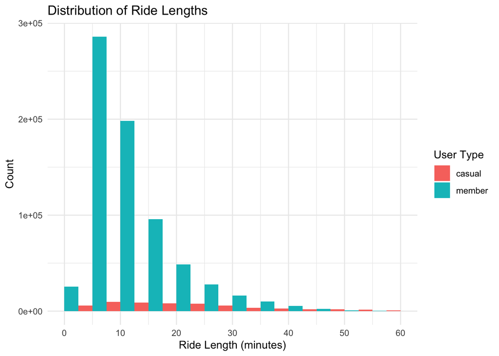

```r
# Visualize ride length distribution
ggplot(all_trips, aes(x = ride_length, fill = member_casual)) +
  geom_histogram(binwidth = 5, position = "dodge") +
  scale_x_continuous(limits = c(0, 60), breaks = seq(0, 60, 10)) +
  labs(title = "Distribution of Ride Lengths",
       x = "Ride Length (minutes)",
       y = "Count",
       fill = "User Type") +
  theme_minimal()
```

### Usage patterns by day of week

Examine the number of rides and average duration for each day of the week.

```r
# 2. Usage patterns by day of week
trips_by_day <- all_trips %>%
  group_by(member_casual, day_of_week) %>%
  summarise(number_of_rides = n(),
            average_duration = mean(ride_length)) %>%
  arrange(member_casual, day_of_week)

print(trips_by_day)
```

```
## # A tibble: 14 × 4
## # Groups:   member_casual [2]
##    member_casual day_of_week number_of_rides average_duration
##    <chr>         <chr>                 <int>            <dbl>
##  1 casual        Fri                    8466             35.0
##  2 casual        Mon                    6672             28.7
##  3 casual        Sat                   13416             38.9
##  4 casual        Sun                   18578             40.9
##  5 casual        Thu                    7729             32.4
##  6 casual        Tue                    7949             32.6
##  7 casual        Wed                    8328             37.8
##  8 member        Fri                  115132             11.1
##  9 member        Mon                  110412             11.1
## 10 member        Sat                   59381             12.4
## 11 member        Sun                   60178             12.9
## 12 member        Thu                  125198             11.1
## 13 member        Tue                  127946             11.3
## 14 member        Wed                  121879             11.2
```

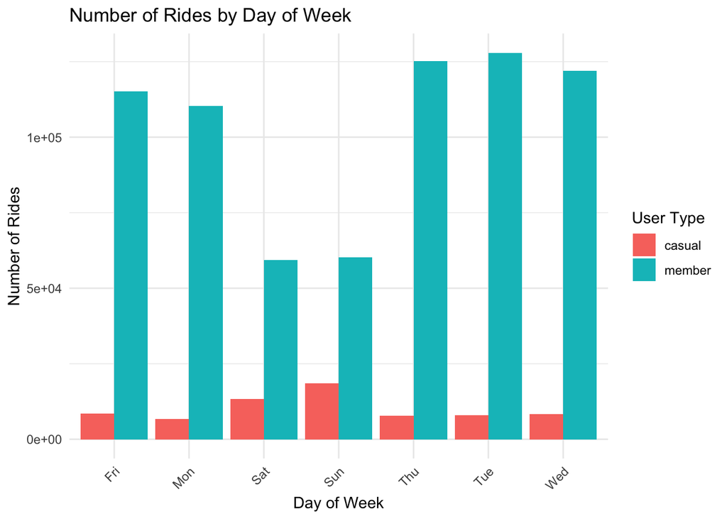

```r
# Visualize number of rides by day of week
ggplot(trips_by_day, aes(x = day_of_week, y = number_of_rides, fill = member_casual)) +
  geom_col(position = "dodge") +
  labs(title = "Number of Rides by Day of Week",
       x = "Day of Week",
       y = "Number of Rides",
       fill = "User Type") +
  theme_minimal() +
  theme(axis.text.x = element_text(angle = 45, hjust = 1))
```

### Popular stations analysis

Identify the top 10 start stations for each user type.

```r
# 3. Popular stations analysis
top_start_stations <- all_trips %>%
  group_by(member_casual, start_station_name) %>%
  summarise(number_of_starts = n()) %>%
  arrange(member_casual, desc(number_of_starts)) %>%
  group_by(member_casual) %>%
  slice_head(n = 10)

print(top_start_stations)
```

```
## # A tibble: 20 × 3
## # Groups:   member_casual [2]
##    member_casual start_station_name           number_of_starts
##    <chr>         <chr>                                   <int>
##  1 casual        HQ QR                                    3556
##  2 casual        Streeter Dr & Grand Ave                  2741
##  3 casual        Lake Shore Dr & Monroe St                2727
##  4 casual        Shedd Aquarium                           1831
##  5 casual        Millennium Park                          1403
##  6 casual        Michigan Ave & Oak St                    1017
##  7 casual        Michigan Ave & Washington St              835
##  8 casual        Dusable Harbor                            829
##  9 casual        Adler Planetarium                         826
## 10 casual        Theater on the Lake                       794
## 11 member        Canal St & Adams St                     13797
## 12 member        Clinton St & Washington Blvd            13434
## 13 member        Clinton St & Madison St                 12889
## 14 member        Kingsbury St & Kinzie St                 8718
## 15 member        Columbus Dr & Randolph St                8515
## 16 member        Canal St & Madison St                    7956
## 17 member        Franklin St & Monroe St                  7008
## 18 member        Michigan Ave & Washington St             6684
## 19 member        Larrabee St & Kingsbury St               6466
## 20 member        Clinton St & Lake St                     6437
```

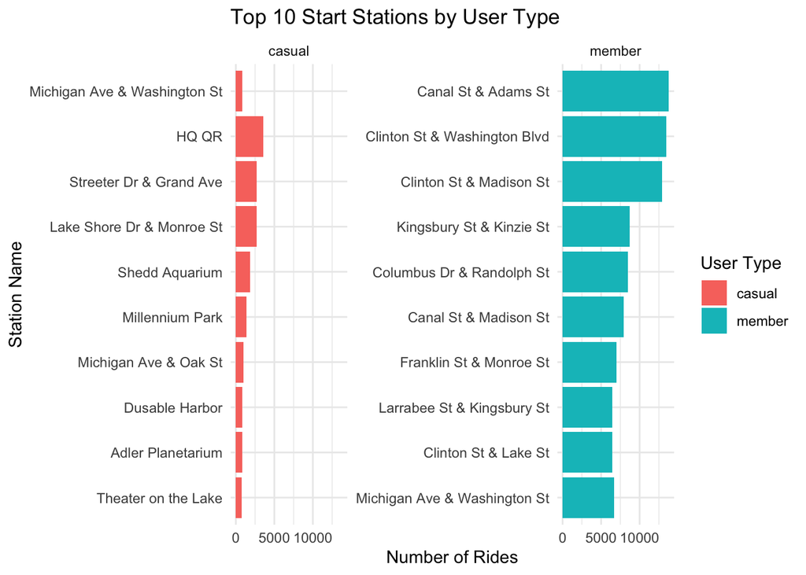

```r
# Visualize top start stations
ggplot(top_start_stations, aes(x = reorder(start_station_name, number_of_starts),
                               y = number_of_starts, fill = member_casual)) +
  geom_col() +
  facet_wrap(~member_casual, scales = "free_y") +
  coord_flip() +
  labs(title = "Top 10 Start Stations by User Type",
       x = "Station Name",
       y = "Number of Rides",
       fill = "User Type") +
  theme_minimal()
```